# Calibration Results Analysis

Marcos J Ribeiro

2025-05-16

## 1 Introduction

In this document, I analyze the calibration results. I calibrated the TFP using the sectoral gross output relative to the sectoral average gross output from the US, from data and model. For the model, I used the results of gross output from previous calibration that I did to US. The objective function that I proposed is:

$$Obj = \sum_i^N \left( \frac{ WGO_i^M -
WGO_i^D }{WGO_i^D} \right)^2$$
Where

$WGO_i^D = GO_i^D/ \bar{GO}_{US}^D$

$WGO_i^M = GO_i^M/ \bar{GO}_{US}^M$

The superscripts M and D means model and data, respectively.

The main advantages of this approach are:

- It is easy to calibrate
- The objective function converges to zero in almost all countries
- It is easy to explain
- The results make economic sense
- The correlation between labor shares from data and the model is 90%
- The correlation between intermediate inputs share from data and the model is also high

Observations:

- I used a dataset 2014.
- The GDP per person employed tnat I used here is from World Bank.
- I didn’t use L=1, instead I used labor (from SEA) per hundred million inhabitants. This makes more sense when comparing country results. I noticed that normalizing L=1 overestimates productivity per worker in low-income countries.

Case 1 L = 1: By equalizing labor endowments, the model forces differences in GDP to be explained by productivity. Low-income countries need higher A to compensate for their lower income levels despite having the same labor input.

Case 2 (actual L): When labor endowments reflect reality, low-income countries’ larger workforces naturally increase output, reducing the need for high A. High-income countries, with smaller workforces, rely on higher productivity to achieve high income levels.

- I removed Cyprus because it is a very small economy and the calibration for this country is very unstable.

## 2 Plots

### 2.1 Weighted GO from data and model - Adjustment

Excluding China Industry only to view better.

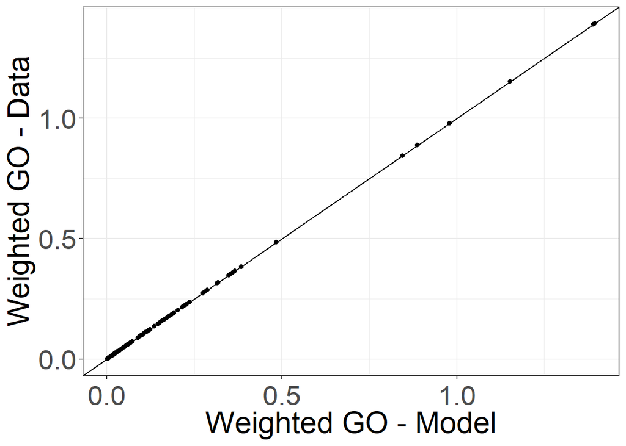

### 2.2 Labor Share from model and data

Plotting model vs. data labor shares.

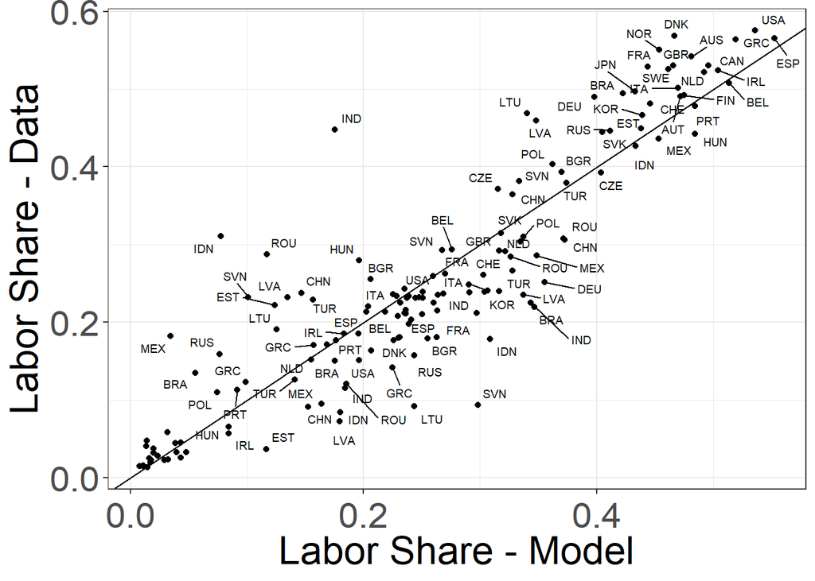

### 2.3 Correlation of labor shares from data and model

The correlation between model and data labor shares is high.

```
## [1] 0.9061398
```

### 2.4 Intermediate Inputs Share from model and data

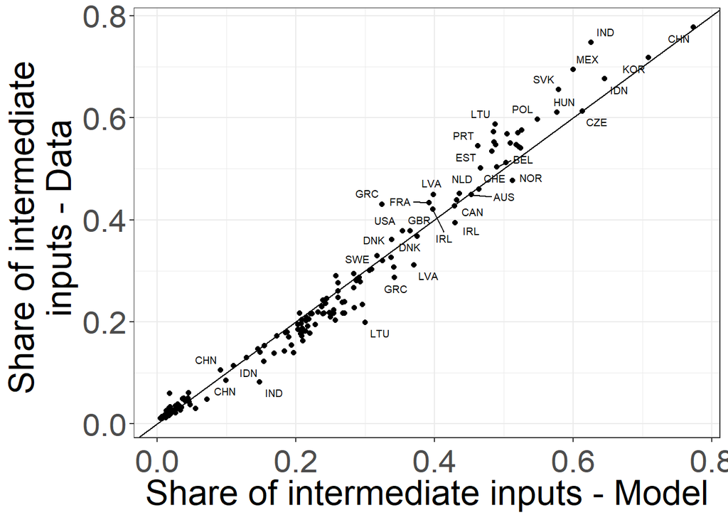

## 3 Calibrated TFP

### 3.1 Descriptive Statistics for TFP

Summarizing TFP statistics by sector. On average, the modern services sector is the most productive sector, followed by traditional services.

|  | sectors | tfp_avg | tfp_min | tfp_max | tfp_sd |
| --- | --- | --- | --- | --- | --- |
| 1 | Agriculture | 2.44 | 0.97 | 4.23 | 0.86 |
| 2 | Industry | 4.45 | 2.85 | 5.96 | 0.75 |
| 3 | Modern Services | 5.4 | 3.1 | 7.68 | 0.9 |
| 4 | Traditional Services | 5.16 | 2.64 | 6.32 | 0.84 |

### 3.2 TFP and GDP per person employed

As we expected, there is a positive correlation between TFP and GDP per person employed in almost all sectors.

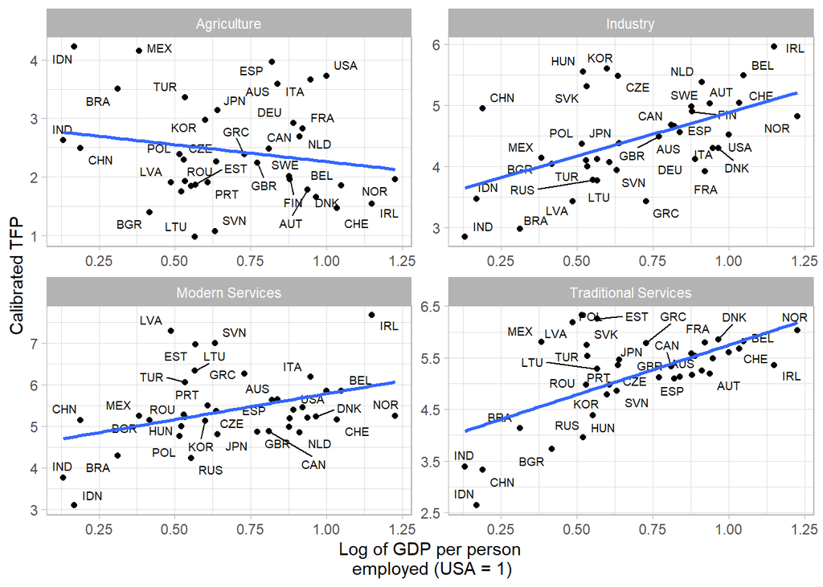

### 3.3 Aggregate TFP and GDP per worker

Aggregate TFP is the sum of sectoral TFP weighted by labor share in each sector. The GDP per person employed is from World Bank.

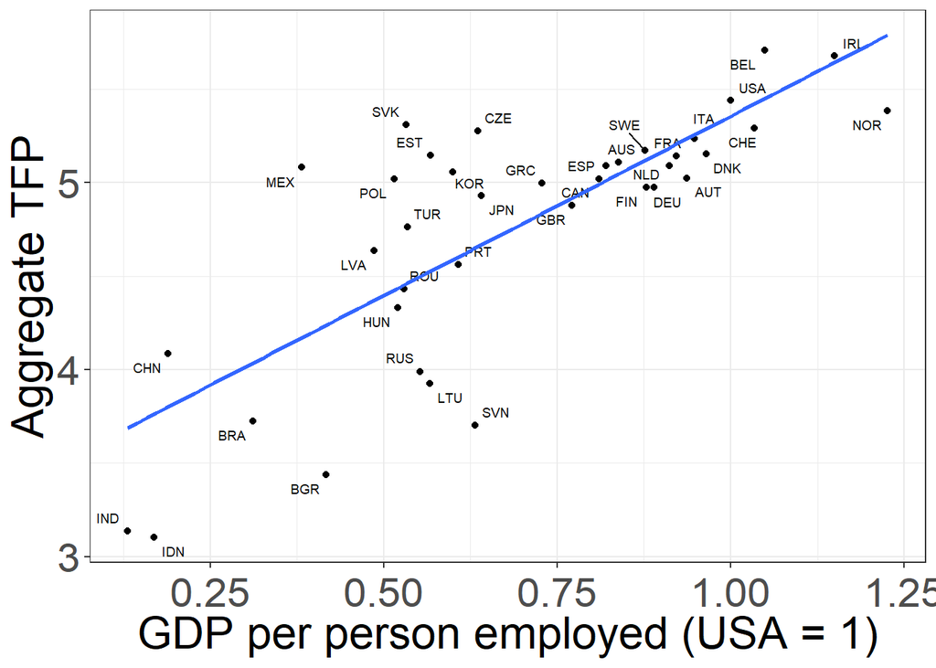